# Prediction Assignment Writeup

Jody9678

2023-10-03

###Install and load the required libraries:

```r
library(ggplot2)
library(caret)
```

###Load the training and testing data:

```r
data_train = read.csv("https://d396qusza40orc.cloudfront.net/predmachlearn/pml-training.csv")
data_test = read.csv("https://d396qusza40orc.cloudfront.net/predmachlearn/pml-testing.csv")
```

```r
head(data_train, 10)
```

```
##     X user_name raw_timestamp_part_1 raw_timestamp_part_2   cvtd_timestamp
## 1   1  carlitos           1323084231               788290 05/12/2011 11:23
## 2   2  carlitos           1323084231               808298 05/12/2011 11:23
## 3   3  carlitos           1323084231               820366 05/12/2011 11:23
## 4   4  carlitos           1323084232               120339 05/12/2011 11:23
## 5   5  carlitos           1323084232               196328 05/12/2011 11:23
## 6   6  carlitos           1323084232               304277 05/12/2011 11:23
## 7   7  carlitos           1323084232               368296 05/12/2011 11:23
## 8   8  carlitos           1323084232               440390 05/12/2011 11:23
## 9   9  carlitos           1323084232               484323 05/12/2011 11:23
## 10 10  carlitos           1323084232               484434 05/12/2011 11:23
##    new_window num_window roll_belt pitch_belt yaw_belt total_accel_belt
## 1          no         11      1.41       8.07    -94.4                3
## 2          no         11      1.41       8.07    -94.4                3
## 3          no         11      1.42       8.07    -94.4                3
```

[output cut: 403 more lines]

###Check the variables:

```r
names(data_train)
```

```
##   [1] "X"                        "user_name"
##   [3] "raw_timestamp_part_1"     "raw_timestamp_part_2"
##   [5] "cvtd_timestamp"           "new_window"
##   [7] "num_window"               "roll_belt"
##   [9] "pitch_belt"               "yaw_belt"
##  [11] "total_accel_belt"         "kurtosis_roll_belt"
##  [13] "kurtosis_picth_belt"      "kurtosis_yaw_belt"
##  [15] "skewness_roll_belt"       "skewness_roll_belt.1"
##  [17] "skewness_yaw_belt"        "max_roll_belt"
##  [19] "max_picth_belt"           "max_yaw_belt"
##  [21] "min_roll_belt"            "min_pitch_belt"
##  [23] "min_yaw_belt"             "amplitude_roll_belt"
##  [25] "amplitude_pitch_belt"     "amplitude_yaw_belt"
##  [27] "var_total_accel_belt"     "avg_roll_belt"
##  [29] "stddev_roll_belt"         "var_roll_belt"
```

[output cut: 65 more lines]

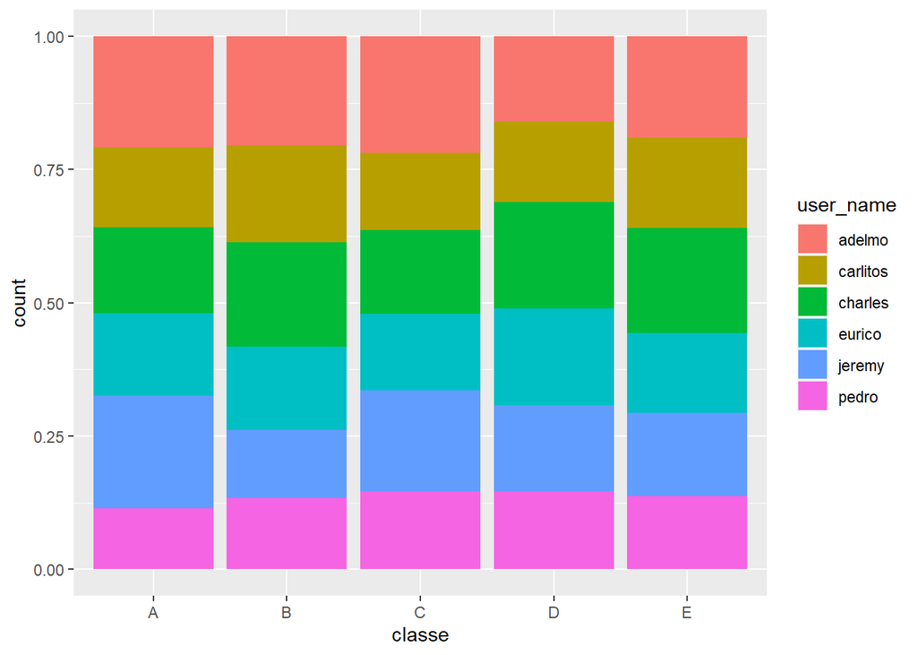

```r
ggplot(data=data_train)+
  geom_bar(mapping= aes(x=classe, fill=user_name), position='fill')
```

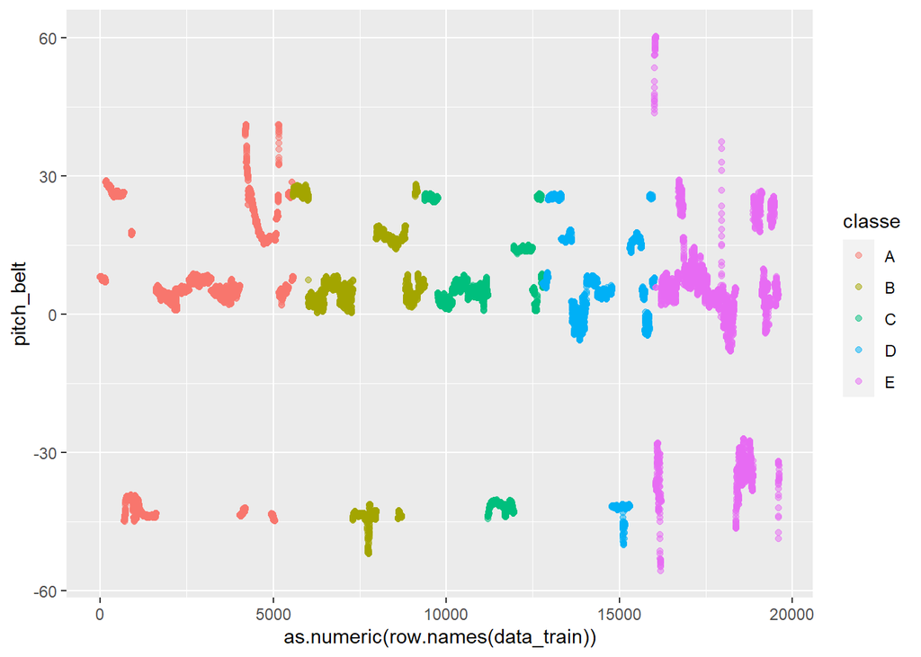

```r
ggplot(data=data_train)+
  geom_point(mapping = aes(x = as.numeric(row.names(data_train)), y = pitch_belt, color=classe), alpha=0.5)
```

The different values of “classe” are clustered; likely due to the way the data was collected or stored. On inspection, the “X” variable appears to correspond to row number:

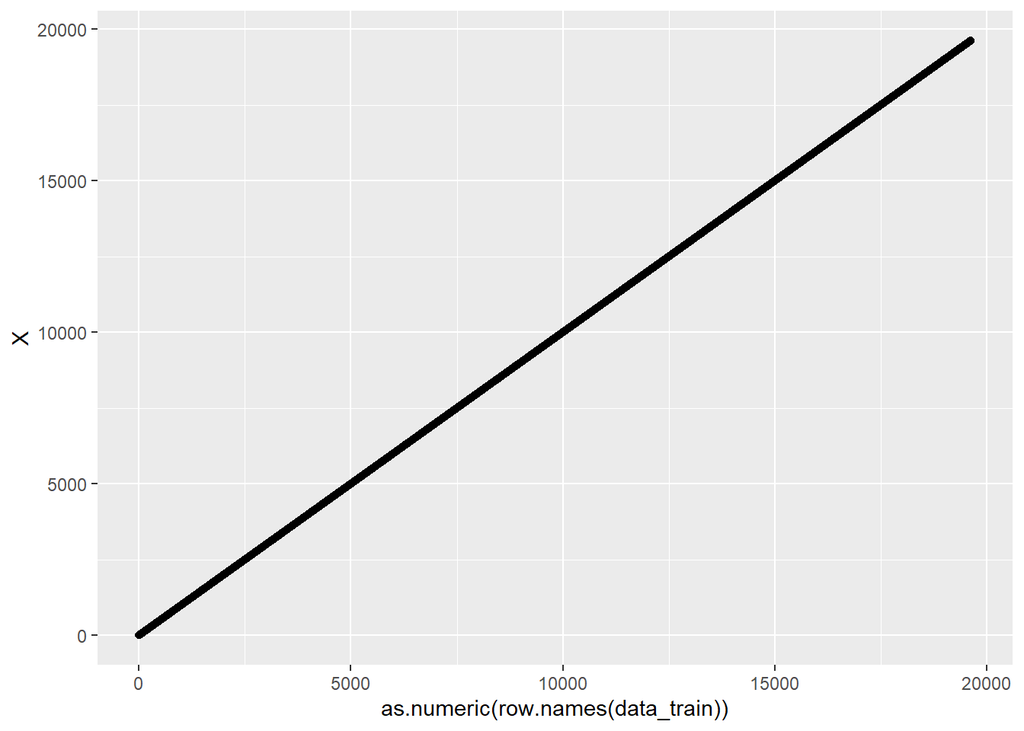

```r
ggplot(data=data_train)+
  geom_point(mapping=aes(x=as.numeric(row.names(data_train)),y=X))
```

To avoid issues related to the above; the data is shuffled and the “X” variable eliminated:

```r
data_train = subset(data_train, select=-c(X))

set.seed(42)
rows <- sample(nrow(data_train))
data_train = data_train[rows,]
rownames(data_train) = NULL
```

```r
head(data_train$classe)
```

```
## [1] "E" "B" "A" "D" "B" "C"
```

```r
names(data_test)
```

```
##   [1] "X"                        "user_name"
##   [3] "raw_timestamp_part_1"     "raw_timestamp_part_2"
##   [5] "cvtd_timestamp"           "new_window"
##   [7] "num_window"               "roll_belt"
##   [9] "pitch_belt"               "yaw_belt"
##  [11] "total_accel_belt"         "kurtosis_roll_belt"
##  [13] "kurtosis_picth_belt"      "kurtosis_yaw_belt"
##  [15] "skewness_roll_belt"       "skewness_roll_belt.1"
##  [17] "skewness_yaw_belt"        "max_roll_belt"
##  [19] "max_picth_belt"           "max_yaw_belt"
##  [21] "min_roll_belt"            "min_pitch_belt"
##  [23] "min_yaw_belt"             "amplitude_roll_belt"
##  [25] "amplitude_pitch_belt"     "amplitude_yaw_belt"
##  [27] "var_total_accel_belt"     "avg_roll_belt"
##  [29] "stddev_roll_belt"         "var_roll_belt"
```

[output cut: 65 more lines]

Note that the testing set does not contain the “classe” variable (which we have to model and predict), and contains a “problem id” variable that is not present in the training set. “Problem id” and “x” variable eliminated from the testing set.

```r
data_test = subset(data_test, select = -c(problem_id, X))
names(data_test)
```

```
##   [1] "user_name"                "raw_timestamp_part_1"
##   [3] "raw_timestamp_part_2"     "cvtd_timestamp"
##   [5] "new_window"               "num_window"
##   [7] "roll_belt"                "pitch_belt"
##   [9] "yaw_belt"                 "total_accel_belt"
##  [11] "kurtosis_roll_belt"       "kurtosis_picth_belt"
##  [13] "kurtosis_yaw_belt"        "skewness_roll_belt"
##  [15] "skewness_roll_belt.1"     "skewness_yaw_belt"
##  [17] "max_roll_belt"            "max_picth_belt"
##  [19] "max_yaw_belt"             "min_roll_belt"
##  [21] "min_pitch_belt"           "min_yaw_belt"
##  [23] "amplitude_roll_belt"      "amplitude_pitch_belt"
##  [25] "amplitude_yaw_belt"       "var_total_accel_belt"
##  [27] "avg_roll_belt"            "stddev_roll_belt"
##  [29] "var_roll_belt"            "avg_pitch_belt"
```

[output cut: 64 more lines]

###Data Cleanup:

#Eliminate high percentage of NaN values:

```r
naCols = which(colMeans(!is.na(data_train)) <= 0.1)
```

```r
data_train = data_train[, -naCols]
```

```r
names(data_train)
```

```
##  [1] "user_name"               "raw_timestamp_part_1"
##  [3] "raw_timestamp_part_2"    "cvtd_timestamp"
##  [5] "new_window"              "num_window"
##  [7] "roll_belt"               "pitch_belt"
##  [9] "yaw_belt"                "total_accel_belt"
## [11] "kurtosis_roll_belt"      "kurtosis_picth_belt"
## [13] "kurtosis_yaw_belt"       "skewness_roll_belt"
## [15] "skewness_roll_belt.1"    "skewness_yaw_belt"
## [17] "max_yaw_belt"            "min_yaw_belt"
## [19] "amplitude_yaw_belt"      "gyros_belt_x"
## [21] "gyros_belt_y"            "gyros_belt_z"
## [23] "accel_belt_x"            "accel_belt_y"
## [25] "accel_belt_z"            "magnet_belt_x"
## [27] "magnet_belt_y"           "magnet_belt_z"
## [29] "roll_arm"                "pitch_arm"
```

[output cut: 31 more lines]

It is apparent that a lot of variables were filtered out with this requirement.

#Explore the variability of the remaining variables. Eliminate variables that exhibit variability near zero, since they do not contain valuable information:

```r
noVariance <- nearZeroVar(data_train)
data_train <- data_train[,-noVariance]
```

```r
names(data_train)
```

```
##  [1] "user_name"            "raw_timestamp_part_1" "raw_timestamp_part_2"
##  [4] "cvtd_timestamp"       "num_window"           "roll_belt"
##  [7] "pitch_belt"           "yaw_belt"             "total_accel_belt"
## [10] "gyros_belt_x"         "gyros_belt_y"         "gyros_belt_z"
## [13] "accel_belt_x"         "accel_belt_y"         "accel_belt_z"
## [16] "magnet_belt_x"        "magnet_belt_y"        "magnet_belt_z"
## [19] "roll_arm"             "pitch_arm"            "yaw_arm"
## [22] "total_accel_arm"      "gyros_arm_x"          "gyros_arm_y"
## [25] "gyros_arm_z"          "accel_arm_x"          "accel_arm_y"
## [28] "accel_arm_z"          "magnet_arm_x"         "magnet_arm_y"
## [31] "magnet_arm_z"         "roll_dumbbell"        "pitch_dumbbell"
## [34] "yaw_dumbbell"         "total_accel_dumbbell" "gyros_dumbbell_x"
## [37] "gyros_dumbbell_y"     "gyros_dumbbell_z"     "accel_dumbbell_x"
## [40] "accel_dumbbell_y"     "accel_dumbbell_z"     "magnet_dumbbell_x"
## [43] "magnet_dumbbell_y"    "magnet_dumbbell_z"    "roll_forearm"
## [46] "pitch_forearm"        "yaw_forearm"          "total_accel_forearm"
## [49] "gyros_forearm_x"      "gyros_forearm_y"      "gyros_forearm_z"
## [52] "accel_forearm_x"      "accel_forearm_y"      "accel_forearm_z"
## [55] "magnet_forearm_x"     "magnet_forearm_y"     "magnet_forearm_z"
## [58] "classe"
```

#Remove extraneous variables from testing set:

```r
data_test = data_test[,-naCols]
data_test = data_test[,-noVariance]
```

```r
names(data_test)
```

```
##  [1] "user_name"            "raw_timestamp_part_1" "raw_timestamp_part_2"
##  [4] "cvtd_timestamp"       "num_window"           "roll_belt"
##  [7] "pitch_belt"           "yaw_belt"             "total_accel_belt"
## [10] "gyros_belt_x"         "gyros_belt_y"         "gyros_belt_z"
## [13] "accel_belt_x"         "accel_belt_y"         "accel_belt_z"
## [16] "magnet_belt_x"        "magnet_belt_y"        "magnet_belt_z"
## [19] "roll_arm"             "pitch_arm"            "yaw_arm"
## [22] "total_accel_arm"      "gyros_arm_x"          "gyros_arm_y"
## [25] "gyros_arm_z"          "accel_arm_x"          "accel_arm_y"
## [28] "accel_arm_z"          "magnet_arm_x"         "magnet_arm_y"
## [31] "magnet_arm_z"         "roll_dumbbell"        "pitch_dumbbell"
## [34] "yaw_dumbbell"         "total_accel_dumbbell" "gyros_dumbbell_x"
## [37] "gyros_dumbbell_y"     "gyros_dumbbell_z"     "accel_dumbbell_x"
## [40] "accel_dumbbell_y"     "accel_dumbbell_z"     "magnet_dumbbell_x"
## [43] "magnet_dumbbell_y"    "magnet_dumbbell_z"    "roll_forearm"
## [46] "pitch_forearm"        "yaw_forearm"          "total_accel_forearm"
## [49] "gyros_forearm_x"      "gyros_forearm_y"      "gyros_forearm_z"
## [52] "accel_forearm_x"      "accel_forearm_y"      "accel_forearm_z"
## [55] "magnet_forearm_x"     "magnet_forearm_y"     "magnet_forearm_z"
```

###Data modeling:

#Create a partition of the data into traininig and validation.

```r
set.seed(42)
inTrain <- createDataPartition(data_train$classe, p=0.7, list=F)
training_data <- data_train[inTrain,]
validation_data <- data_train[-inTrain,]
```

###Generate decision tree:

```r
trainControl <- trainControl(method="cv", number=3, verboseIter=F)
modelFit1 = train(classe~., data=training_data, method="rpart", trControl = trainControl, tuneLength = 5)
```

```r
modelFit1
```

```
## CART
##
## 13737 samples
##    57 predictor
##     5 classes: 'A', 'B', 'C', 'D', 'E'
##
## No pre-processing
## Resampling: Cross-Validated (3 fold)
## Summary of sample sizes: 9157, 9157, 9160
## Resampling results across tuning parameters:
##
##   cp          Accuracy   Kappa
##   0.03341471  0.5893475  0.48294197
##   0.03692402  0.4878191  0.32912111
##   0.03951785  0.4680099  0.30525588
##   0.04489201  0.4501788  0.28369405
##   0.11311159  0.3372702  0.08089327
##
## Accuracy was used to select the optimal model using the largest value.
## The final value used for the model was cp = 0.03341471.
```

#Visualize decision tree:

```r
library(rattle)
```

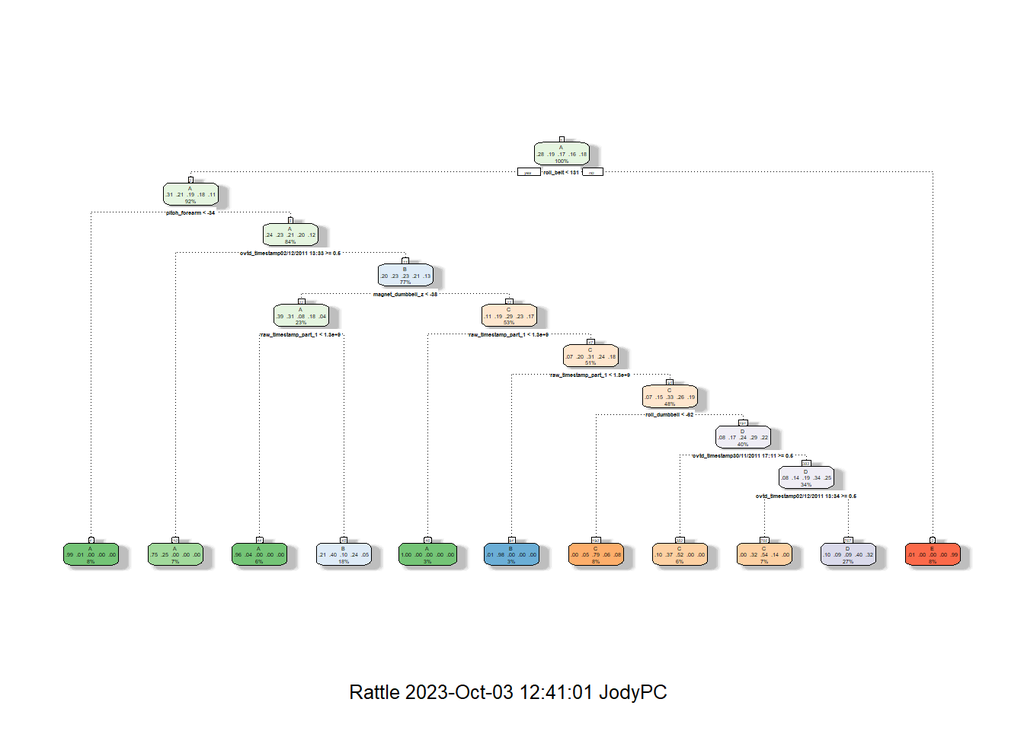

```r
fancyRpartPlot(modelFit1$finalModel)
```

#Evaluate the model by predicting with validation data and constructing the confusion matrix:

```r
prediction1 <- predict(modelFit1, validation_data)
confusionMatrix1 <- confusionMatrix(prediction1, factor(validation_data$classe))
confusionMatrix1
```

```
## Confusion Matrix and Statistics
##
##           Reference
## Prediction    A    B    C    D    E
##          A 1240  109    1    0    0
##          B  218  594  125  270   70
##          C   41  279  756   64   36
##          D  173  157  144  630  469
##          E    2    0    0    0  507
##
## Overall Statistics
##
##                Accuracy : 0.6333
##                  95% CI : (0.6208, 0.6456)
##     No Information Rate : 0.2845
##     P-Value [Acc > NIR] : < 2.2e-16
##
##                   Kappa : 0.5406
##
##  Mcnemar's Test P-Value : < 2.2e-16
##
## Statistics by Class:
##
##                      Class: A Class: B Class: C Class: D Class: E
## Sensitivity            0.7407   0.5215   0.7368   0.6535  0.46858
## Specificity            0.9739   0.8561   0.9136   0.8084  0.99958
## Pos Pred Value         0.9185   0.4652   0.6429   0.4005  0.99607
## Neg Pred Value         0.9043   0.8817   0.9427   0.9225  0.89304
## Prevalence             0.2845   0.1935   0.1743   0.1638  0.18386
## Detection Rate         0.2107   0.1009   0.1285   0.1071  0.08615
## Detection Prevalence   0.2294   0.2170   0.1998   0.2673  0.08649
## Balanced Accuracy      0.8573   0.6888   0.8252   0.7309  0.73408
```

Based on the validation performance, we expect this model to have about 60% out of sample accuracy.

#Predict using testing set:

```r
predict(modelFit1, data_test)
```

```
##  [1] B C C A A D D C A A D C B A D D D B B B
## Levels: A B C D E
```

###Generate random forest, and evaluate its performance on the validation set:

```r
modelFit2 = train(classe~., data=training_data, method="rf", trControl = trainControl, tuneLength = 5)
modelFit2
```

```
## Random Forest
##
## 13737 samples
##    57 predictor
##     5 classes: 'A', 'B', 'C', 'D', 'E'
##
## No pre-processing
## Resampling: Cross-Validated (3 fold)
## Summary of sample sizes: 9159, 9158, 9157
## Resampling results across tuning parameters:
##
##   mtry  Accuracy   Kappa
##    2    0.9860958  0.9824087
##   21    0.9983986  0.9979745
##   40    0.9985441  0.9981586
##   59    0.9981073  0.9976060
##   79    0.9971610  0.9964091
##
## Accuracy was used to select the optimal model using the largest value.
## The final value used for the model was mtry = 40.
```

```r
prediction2 <- predict(modelFit2, validation_data)
confusionMatrix2 <- confusionMatrix(prediction2, factor(validation_data$classe))
confusionMatrix2
```

```
## Confusion Matrix and Statistics
##
##           Reference
## Prediction    A    B    C    D    E
##          A 1674    1    0    0    0
##          B    0 1138    0    0    0
##          C    0    0 1026    1    0
##          D    0    0    0  963    2
##          E    0    0    0    0 1080
##
## Overall Statistics
##
##                Accuracy : 0.9993
##                  95% CI : (0.9983, 0.9998)
##     No Information Rate : 0.2845
##     P-Value [Acc > NIR] : < 2.2e-16
##
##                   Kappa : 0.9991
##
##  Mcnemar's Test P-Value : NA
##
## Statistics by Class:
##
##                      Class: A Class: B Class: C Class: D Class: E
## Sensitivity            1.0000   0.9991   1.0000   0.9990   0.9982
## Specificity            0.9998   1.0000   0.9998   0.9996   1.0000
## Pos Pred Value         0.9994   1.0000   0.9990   0.9979   1.0000
## Neg Pred Value         1.0000   0.9998   1.0000   0.9998   0.9996
## Prevalence             0.2845   0.1935   0.1743   0.1638   0.1839
## Detection Rate         0.2845   0.1934   0.1743   0.1636   0.1835
## Detection Prevalence   0.2846   0.1934   0.1745   0.1640   0.1835
## Balanced Accuracy      0.9999   0.9996   0.9999   0.9993   0.9991
```

Random forest predicted to have 99% accuracy using sample.

#Use random forest to predict on the test set:

```r
predict(modelFit2, data_test)
```

```
##  [1] B A B A A E D B A A B C B A E E A B B B
## Levels: A B C D E
```

Additional analysis and iterations would yield insignificant decimal changes in accuracy over the above model, so we stop the analysis and use random forest for the quiz answers.